# Employee Transportation Mode Prediction

## R Markdown

This project is about predicting what mode of transport employees prefers to commute to their office. The dataset “Cars-dataset” includes employee information about their mode of transport as well as their personal and professional details like age, salary, work exp. The goal of this project is to predict whether or not an employee will use Car as a mode of transport. Also, which variables are a significant predictor behind this decision.

```r
#Reading the csv file
raw_data <- read.csv('CarsData.csv')
summary(raw_data)
```

```
##       Age           Gender       Engineer           MBA
##  Min.   :18.00   Female:120   Min.   :0.0000   Min.   :0.0000
##  1st Qu.:25.00   Male  :297   1st Qu.:1.0000   1st Qu.:0.0000
##  Median :27.00                Median :1.0000   Median :0.0000
##  Mean   :27.33                Mean   :0.7506   Mean   :0.2614
##  3rd Qu.:29.00                3rd Qu.:1.0000   3rd Qu.:1.0000
##  Max.   :43.00                Max.   :1.0000   Max.   :1.0000
##     Work.Exp          Salary         Distance       license
##  Min.   : 0.000   Min.   : 6.50   Min.   : 3.2   Min.   :0.0000
##  1st Qu.: 3.000   1st Qu.: 9.60   1st Qu.: 8.6   1st Qu.:0.0000
##  Median : 5.000   Median :13.00   Median :10.9   Median :0.0000
##  Mean   : 5.873   Mean   :15.42   Mean   :11.3   Mean   :0.2038
##  3rd Qu.: 8.000   3rd Qu.:14.90   3rd Qu.:13.6   3rd Qu.:0.0000
##  Max.   :24.000   Max.   :57.00   Max.   :23.4   Max.   :1.0000
##             Transport
##  2Wheeler        : 83
##  Car             : 35
##  Public Transport:299
##
##
##
```

```r
str(raw_data)
```

```
## 'data.frame':    417 obs. of  9 variables:
##  $ Age      : int  28 24 27 25 25 21 23 23 24 28 ...
##  $ Gender   : Factor w/ 2 levels "Female","Male": 2 2 1 2 1 2 2 2 2 2 ...
##  $ Engineer : int  1 1 1 0 0 0 1 0 1 1 ...
##  $ MBA      : int  0 0 0 0 0 0 1 0 0 0 ...
##  $ Work.Exp : int  5 6 9 1 3 3 3 0 4 6 ...
##  $ Salary   : num  14.4 10.6 15.5 7.6 9.6 9.5 11.7 6.5 8.5 13.7 ...
##  $ Distance : num  5.1 6.1 6.1 6.3 6.7 7.1 7.2 7.3 7.5 7.5 ...
##  $ license  : int  0 0 0 0 0 0 0 0 0 1 ...
##  $ Transport: Factor w/ 3 levels "2Wheeler","Car",..: 1 1 1 1 1 1 1 1 1 1 ...
```

## Initial Observations

```r
raw_data<-na.omit(raw_data)
```

```r
#library(dlookr)
#eda_report(raw_data,target = 'Transport',output_format = 'html', output_file ='eda_report1.html')
```

```r
htmltools::includeHTML("eda_report1.htm")
```

# Exploratory Data Analysis Report

Report by dlookr package

2019-08-02

# 1 Introduction

The EDA Report provides exploratory data analysis information on objects that inherit data.frame and data.frame.

## 1.1 Information of Dataset

The dataset that generated the EDA Report is an **‘data.frame’** object. It consists of **417 observations** and **9 variables**.

## 1.2 Information of Variables

The variable information of the data set that generated the EDA Report is shown in the following table.:

Information of Variables

| variables | types | missing_count | missing_percent | unique_count | unique_rate |
| --- | --- | --- | --- | --- | --- |
| Age | integer | 0 | 0 | 25 | 0.0599520 |
| Gender | factor | 0 | 0 | 2 | 0.0047962 |
| Engineer | integer | 0 | 0 | 2 | 0.0047962 |
| MBA | integer | 0 | 0 | 2 | 0.0047962 |
| Work.Exp | integer | 0 | 0 | 24 | 0.0575540 |
| Salary | numeric | 0 | 0 | 116 | 0.2781775 |
| Distance | numeric | 0 | 0 | 137 | 0.3285372 |
| license | integer | 0 | 0 | 2 | 0.0047962 |
| Transport | factor | 0 | 0 | 3 | 0.0071942 |

The target variable of the data is **‘Transport’**, and the data type of the variable is **factor**.

## 1.3 About EDA Report

EDA reports provide information and visualization results that support the EDA process. In particular, it provides a variety of information to understand the relationship between the target variable and the rest of the variables of interest.

# 2 Univariate Analysis

## 2.1 Descriptive Statistics

edaData  
9 Variables 417 Observations

Age

| n | missing | distinct | Info | Mean | Gmd | .05 | .10 | .25 | .50 | .75 | .90 | .95 |
| --- | --- | --- | --- | --- | --- | --- | --- | --- | --- | --- | --- | --- |
| 417 | 0 | 25 | 0.991 | 27.33 | 4.415 | 22.0 | 23.0 | 25.0 | 27.0 | 29.0 | 32.4 | 37.0 |

lowest : 18 19 20 21 22 , highest: 38 39 40 42 43

Gender

| n | missing | distinct |
| --- | --- | --- |
| 417 | 0 | 2 |

```
 Value      Female   Male
 Frequency     120    297
 Proportion  0.288  0.712
```

Engineer

| n | missing | distinct | Info | Sum | Mean | Gmd |
| --- | --- | --- | --- | --- | --- | --- |
| 417 | 0 | 2 | 0.562 | 313 | 0.7506 | 0.3753 |

MBA

| n | missing | distinct | Info | Sum | Mean | Gmd |
| --- | --- | --- | --- | --- | --- | --- |
| 417 | 0 | 2 | 0.579 | 109 | 0.2614 | 0.3871 |

Work.Exp

| n | missing | distinct | Info | Mean | Gmd | .05 | .10 | .25 | .50 | .75 | .90 | .95 |
| --- | --- | --- | --- | --- | --- | --- | --- | --- | --- | --- | --- | --- |
| 417 | 0 | 24 | 0.992 | 5.873 | 4.959 | 0 | 1 | 3 | 5 | 8 | 12 | 18 |

lowest : 0 1 2 3 4 , highest: 19 20 21 22 24

Salary

| n | missing | distinct | Info | Mean | Gmd | .05 | .10 | .25 | .50 | .75 | .90 | .95 |
| --- | --- | --- | --- | --- | --- | --- | --- | --- | --- | --- | --- | --- |
| 417 | 0 | 116 | 1 | 15.42 | 8.681 | 7.58 | 8.46 | 9.60 | 13.00 | 14.90 | 28.74 | 41.92 |

lowest : 6.5 6.6 6.7 6.8 6.9 , highest: 50.0 51.0 52.0 55.0 57.0

Distance

| n | missing | distinct | Info | Mean | Gmd | .05 | .10 | .25 | .50 | .75 | .90 | .95 |
| --- | --- | --- | --- | --- | --- | --- | --- | --- | --- | --- | --- | --- |
| 417 | 0 | 137 | 1 | 11.3 | 4.158 | 6.10 | 7.00 | 8.60 | 10.90 | 13.60 | 16.34 | 17.92 |

lowest : 3.2 3.3 4.1 4.5 4.6 , highest: 21.3 21.4 21.5 22.8 23.4

license

| n | missing | distinct | Info | Sum | Mean | Gmd |
| --- | --- | --- | --- | --- | --- | --- |
| 417 | 0 | 2 | 0.487 | 85 | 0.2038 | 0.3254 |

Transport

| n | missing | distinct |
| --- | --- | --- |
| 417 | 0 | 3 |

```
 Value              2Wheeler              Car Public Transport
 Frequency                83               35              299
 Proportion            0.199            0.084            0.717
```

## 2.2 Normality Test of Numerical Variables

### 2.2.1 Statistics and Visualization of (Sample) Data

**[ Age ]**

normality test : Shapiro-Wilk normality test

```
 statistic : 0.92319,  p-value : 8.95723E-14
```

skewness and kurtosis

| type | skewness | kurtosis |
| --- | --- | --- |
| original | 1.0948278 | 4.679769 |
| log transformation | 0.5607251 | 3.804252 |
| sqrt transformation | 0.8293072 | 4.157339 |

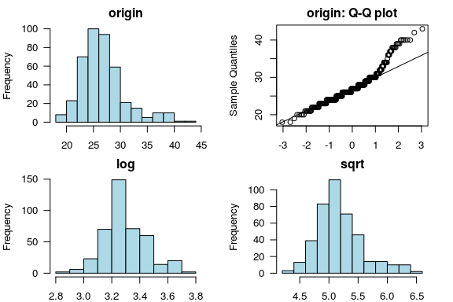

**[ Engineer ]**

normality test : Shapiro-Wilk normality test

```
 statistic : 0.5379,  p-value : 1.2651E-31
```

skewness and kurtosis

| type | skewness | kurtosis |
| --- | --- | --- |
| original | -1.158397 | 2.341884 |
| log transformation | NaN | NaN |
| sqrt transformation | -1.158397 | 2.341884 |

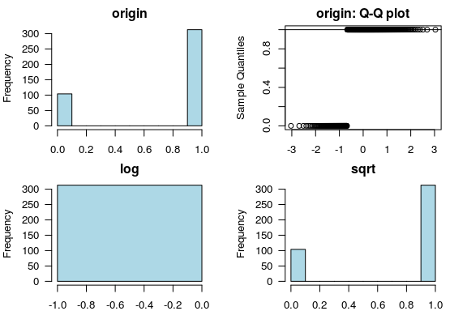

**[ MBA ]**

normality test : Shapiro-Wilk normality test

```
 statistic : 0.54781,  p-value : 2.31535E-31
```

skewness and kurtosis

| type | skewness | kurtosis |
| --- | --- | --- |
| original | 1.086087 | 2.179584 |
| log transformation | NaN | NaN |
| sqrt transformation | 1.086087 | 2.179584 |

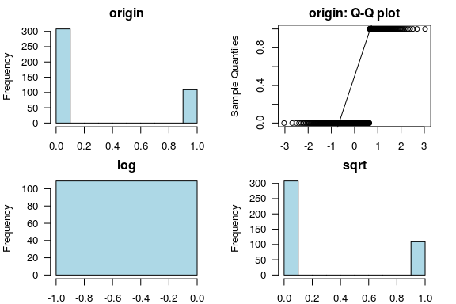

**[ Work.Exp ]**

normality test : Shapiro-Wilk normality test

```
 statistic : 0.85442,  p-value : 3.11053E-19
```

skewness and kurtosis

| type | skewness | kurtosis |
| --- | --- | --- |
| original | 1.5232247 | 5.306204 |
| log transformation | NaN | NaN |
| sqrt transformation | 0.0513144 | 3.449590 |

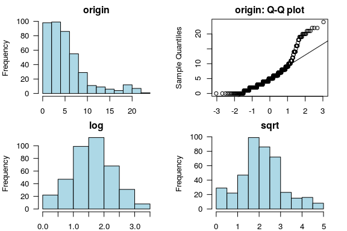

**[ Salary ]**

normality test : Shapiro-Wilk normality test

```
 statistic : 0.69346,  p-value : 7.56383E-27
```

skewness and kurtosis

| type | skewness | kurtosis |
| --- | --- | --- |
| original | 2.285487 | 7.834369 |
| log transformation | 1.118804 | 4.073967 |
| sqrt transformation | 1.739171 | 5.749422 |

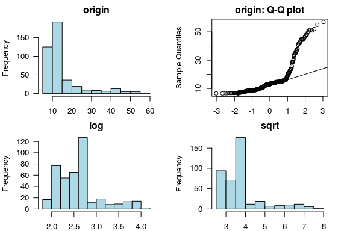

**[ Distance ]**

normality test : Shapiro-Wilk normality test

```
 statistic : 0.97826,  p-value : 6.67592E-06
```

skewness and kurtosis

| type | skewness | kurtosis |
| --- | --- | --- |
| original | 0.5496466 | 3.060981 |
| log transformation | -0.3410430 | 3.111946 |
| sqrt transformation | 0.1274560 | 2.759124 |

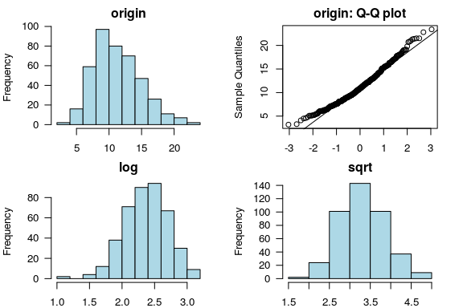

**[ license ]**

normality test : Shapiro-Wilk normality test

```
 statistic : 0.4939,  p-value : 9.719E-33
```

skewness and kurtosis

| type | skewness | kurtosis |
| --- | --- | --- |
| original | 1.470342 | 3.161906 |
| log transformation | NaN | NaN |
| sqrt transformation | 1.470342 | 3.161906 |

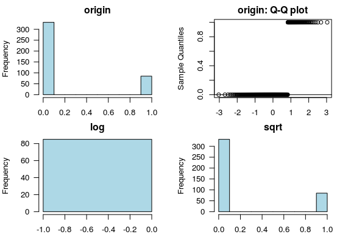

# 3 Relationship Between Variables

## 3.1 Correlation Coefficient

### 3.1.1 Correlation Coefficient by Variable Combination

Table of correlation coefficients (0.5 or more)

| Variable1 | Variable2 | Correlation Coefficient |
| --- | --- | --- |
| Salary | Work.Exp | 0.9318574 |
| Work.Exp | Age | 0.9244489 |
| Salary | Age | 0.8579114 |

### 3.1.2 Correlation Plot of Numerical Variables

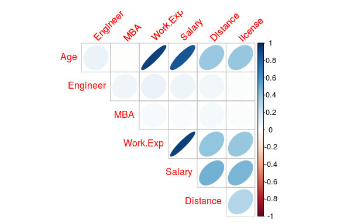

# 4 Target based Analysis

## 4.1 Grouped Descriptive Statistics

### 4.1.1 Grouped Numerical Variables

**[ Age ]**  
* Distribution of Age

Distribution of Age

|  | total | Public Transport | Car | 2Wheeler |
| --- | --- | --- | --- | --- |
| n | 417.00 | 299.00 | 35.00 | 83.00 |
| NA | 0.00 | 0.00 | 0.00 | 0.00 |
| mean | 27.33 | 26.81 | 36.71 | 25.27 |
| sd | 4.16 | 2.96 | 3.39 | 2.86 |
| se(mean) | 0.20 | 0.17 | 0.57 | 0.31 |
| IQR | 4.00 | 4.00 | 5.00 | 4.00 |
| skewness | 1.10 | 0.17 | -0.39 | 0.54 |
| kurtosis | 1.71 | 0.50 | -0.80 | 0.93 |
| 0% | 18.00 | 18.00 | 30.00 | 18.00 |
| 1% | 20.00 | 20.00 | 30.34 | 19.64 |
| 5% | 22.00 | 22.00 | 31.00 | 21.10 |
| 10% | 23.00 | 23.00 | 32.00 | 22.00 |
| 20% | 24.00 | 24.00 | 33.00 | 23.00 |
| 25% | 25.00 | 25.00 | 34.00 | 23.00 |
| 30% | 25.00 | 25.00 | 34.40 | 24.00 |
| 40% | 26.00 | 26.00 | 37.00 | 24.00 |
| 50% | 27.00 | 27.00 | 38.00 | 25.00 |
| 60% | 27.60 | 27.00 | 38.00 | 26.00 |
| 70% | 28.00 | 28.00 | 39.00 | 26.00 |
| 75% | 29.00 | 29.00 | 39.00 | 27.00 |
| 80% | 30.00 | 29.00 | 40.00 | 28.00 |
| 90% | 32.40 | 30.00 | 40.00 | 29.00 |
| 95% | 37.00 | 32.00 | 40.60 | 30.00 |
| 99% | 40.00 | 34.02 | 42.66 | 34.00 |
| 100% | 43.00 | 36.00 | 43.00 | 34.00 |

* Visualization of Distribution

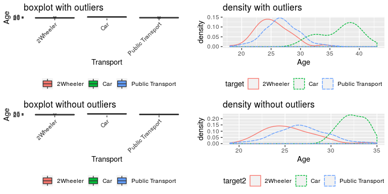

**[ Engineer ]**  
* Distribution of Engineer

Distribution of Engineer

|  | total | Public Transport | Car | 2Wheeler |
| --- | --- | --- | --- | --- |
| n | 417.00 | 299.00 | 35.00 | 83.00 |
| NA | 0.00 | 0.00 | 0.00 | 0.00 |
| mean | 0.75 | 0.75 | 0.86 | 0.72 |
| sd | 0.43 | 0.44 | 0.36 | 0.45 |
| se(mean) | 0.02 | 0.03 | 0.06 | 0.05 |
| IQR | 0.00 | 1.00 | 0.00 | 1.00 |
| skewness | -1.16 | -1.13 | -2.13 | -1.01 |
| kurtosis | -0.65 | -0.72 | 2.70 | -1.00 |
| 0% | 0.00 | 0.00 | 0.00 | 0.00 |
| 1% | 0.00 | 0.00 | 0.00 | 0.00 |
| 5% | 0.00 | 0.00 | 0.00 | 0.00 |
| 10% | 0.00 | 0.00 | 0.00 | 0.00 |
| 20% | 0.00 | 0.00 | 1.00 | 0.00 |
| 25% | 1.00 | 0.00 | 1.00 | 0.00 |
| 30% | 1.00 | 1.00 | 1.00 | 1.00 |
| 40% | 1.00 | 1.00 | 1.00 | 1.00 |
| 50% | 1.00 | 1.00 | 1.00 | 1.00 |
| 60% | 1.00 | 1.00 | 1.00 | 1.00 |
| 70% | 1.00 | 1.00 | 1.00 | 1.00 |
| 75% | 1.00 | 1.00 | 1.00 | 1.00 |
| 80% | 1.00 | 1.00 | 1.00 | 1.00 |
| 90% | 1.00 | 1.00 | 1.00 | 1.00 |
| 95% | 1.00 | 1.00 | 1.00 | 1.00 |
| 99% | 1.00 | 1.00 | 1.00 | 1.00 |
| 100% | 1.00 | 1.00 | 1.00 | 1.00 |

* Visualization of Distribution

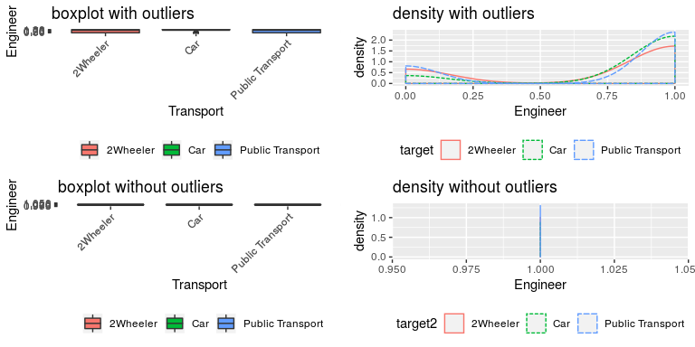

**[ MBA ]**  
* Distribution of MBA

Distribution of MBA

|  | total | Public Transport | Car | 2Wheeler |
| --- | --- | --- | --- | --- |
| n | 417.00 | 299.00 | 35.00 | 83.00 |
| NA | 0.00 | 0.00 | 0.00 | 0.00 |
| mean | 0.26 | 0.28 | 0.26 | 0.20 |
| sd | 0.44 | 0.45 | 0.44 | 0.41 |
| se(mean) | 0.02 | 0.03 | 0.07 | 0.04 |
| IQR | 1.00 | 1.00 | 0.50 | 0.00 |
| skewness | 1.09 | 1.00 | 1.16 | 1.49 |
| kurtosis | -0.82 | -1.01 | -0.69 | 0.22 |
| 0% | 0.00 | 0.00 | 0.00 | 0.00 |
| 1% | 0.00 | 0.00 | 0.00 | 0.00 |
| 5% | 0.00 | 0.00 | 0.00 | 0.00 |
| 10% | 0.00 | 0.00 | 0.00 | 0.00 |
| 20% | 0.00 | 0.00 | 0.00 | 0.00 |
| 25% | 0.00 | 0.00 | 0.00 | 0.00 |
| 30% | 0.00 | 0.00 | 0.00 | 0.00 |
| 40% | 0.00 | 0.00 | 0.00 | 0.00 |
| 50% | 0.00 | 0.00 | 0.00 | 0.00 |
| 60% | 0.00 | 0.00 | 0.00 | 0.00 |
| 70% | 0.00 | 0.00 | 0.00 | 0.00 |
| 75% | 1.00 | 1.00 | 0.50 | 0.00 |
| 80% | 1.00 | 1.00 | 1.00 | 0.60 |
| 90% | 1.00 | 1.00 | 1.00 | 1.00 |
| 95% | 1.00 | 1.00 | 1.00 | 1.00 |
| 99% | 1.00 | 1.00 | 1.00 | 1.00 |
| 100% | 1.00 | 1.00 | 1.00 | 1.00 |

* Visualization of Distribution

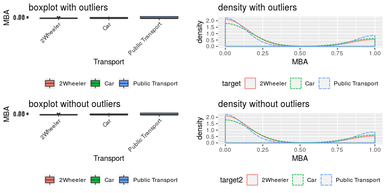

**[ Work.Exp ]**  
* Distribution of Work.Exp

Distribution of Work.Exp

|  | total | Public Transport | Car | 2Wheeler |
| --- | --- | --- | --- | --- |
| n | 417.00 | 299.00 | 35.00 | 83.00 |
| NA | 0.00 | 0.00 | 0.00 | 0.00 |
| mean | 5.87 | 5.01 | 17.51 | 4.06 |
| sd | 4.82 | 3.17 | 3.99 | 3.32 |
| se(mean) | 0.24 | 0.18 | 0.67 | 0.36 |
| IQR | 5.00 | 4.00 | 6.00 | 4.00 |
| skewness | 1.53 | 0.94 | -0.66 | 0.91 |
| kurtosis | 2.35 | 1.50 | -0.71 | 0.83 |
| 0% | 0.00 | 0.00 | 10.00 | 0.00 |
| 1% | 0.00 | 0.00 | 10.00 | 0.00 |
| 5% | 0.00 | 0.00 | 10.00 | 0.00 |
| 10% | 1.00 | 1.00 | 11.00 | 0.00 |
| 20% | 2.00 | 2.00 | 14.00 | 1.00 |
| 25% | 3.00 | 3.00 | 14.00 | 2.00 |
| 30% | 3.00 | 3.00 | 16.00 | 2.00 |
| 40% | 4.00 | 4.00 | 18.00 | 2.00 |
| 50% | 5.00 | 5.00 | 19.00 | 4.00 |
| 60% | 6.00 | 5.00 | 19.40 | 5.00 |
| 70% | 7.00 | 6.00 | 20.00 | 5.00 |
| 75% | 8.00 | 7.00 | 20.00 | 6.00 |
| 80% | 8.00 | 7.00 | 21.00 | 7.00 |
| 90% | 12.00 | 9.00 | 21.60 | 8.00 |
| 95% | 18.00 | 10.10 | 22.00 | 9.90 |
| 99% | 21.00 | 16.00 | 23.32 | 14.18 |
| 100% | 24.00 | 18.00 | 24.00 | 15.00 |

* Visualization of Distribution

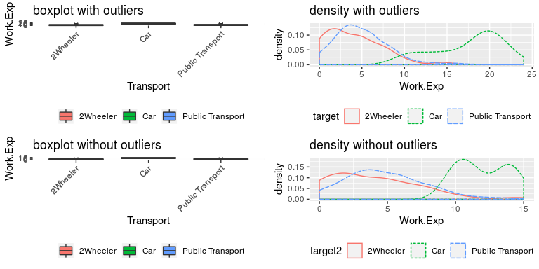

**[ Salary ]**  
* Distribution of Salary

Distribution of Salary

|  | total | Public Transport | Car | 2Wheeler |
| --- | --- | --- | --- | --- |
| n | 417.00 | 299.00 | 35.00 | 83.00 |
| NA | 0.00 | 0.00 | 0.00 | 0.00 |
| mean | 15.42 | 13.17 | 41.29 | 12.61 |
| sd | 9.67 | 4.81 | 10.01 | 6.05 |
| se(mean) | 0.47 | 0.28 | 1.69 | 0.66 |
| IQR | 5.30 | 4.85 | 10.50 | 5.90 |
| skewness | 2.29 | 2.03 | -1.19 | 2.06 |
| kurtosis | 4.91 | 6.25 | 1.47 | 5.28 |
| 0% | 6.50 | 6.50 | 15.80 | 6.50 |
| 1% | 6.80 | 6.80 | 15.83 | 6.66 |
| 5% | 7.58 | 7.69 | 16.67 | 6.90 |
| 10% | 8.46 | 8.50 | 31.74 | 7.12 |
| 20% | 8.90 | 8.90 | 34.80 | 8.50 |
| 25% | 9.60 | 9.80 | 37.00 | 8.75 |
| 30% | 10.40 | 10.54 | 38.58 | 8.80 |
| 40% | 12.34 | 11.98 | 41.96 | 9.40 |
| 50% | 13.00 | 12.90 | 43.00 | 10.60 |
| 60% | 13.90 | 13.80 | 45.00 | 12.80 |
| 70% | 14.70 | 14.60 | 45.80 | 13.70 |
| 75% | 14.90 | 14.65 | 47.50 | 14.65 |
| 80% | 15.80 | 14.84 | 48.40 | 14.90 |
| 90% | 28.74 | 16.52 | 51.00 | 20.50 |
| 95% | 41.92 | 21.90 | 52.90 | 23.72 |
| 99% | 51.00 | 34.80 | 56.32 | 36.92 |
| 100% | 57.00 | 36.60 | 57.00 | 37.00 |

* Visualization of Distribution

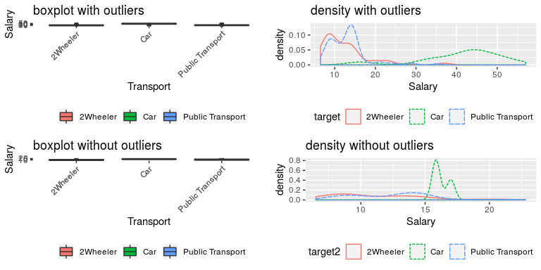

**[ Distance ]**  
* Distribution of Distance

Distribution of Distance

|  | total | Public Transport | Car | 2Wheeler |
| --- | --- | --- | --- | --- |
| n | 417.00 | 299.00 | 35.00 | 83.00 |
| NA | 0.00 | 0.00 | 0.00 | 0.00 |
| mean | 11.30 | 10.32 | 17.88 | 12.04 |
| sd | 3.70 | 3.01 | 2.67 | 3.32 |
| se(mean) | 0.18 | 0.17 | 0.45 | 0.36 |
| IQR | 5.00 | 4.10 | 3.75 | 4.10 |
| skewness | 0.55 | 0.28 | 0.26 | 0.17 |
| kurtosis | 0.08 | -0.38 | -0.82 | -0.20 |
| 0% | 3.20 | 3.20 | 14.10 | 5.10 |
| 1% | 4.63 | 4.49 | 14.10 | 5.92 |
| 5% | 6.10 | 5.87 | 14.10 | 6.74 |
| 10% | 7.00 | 6.48 | 14.40 | 7.50 |
| 20% | 8.10 | 7.70 | 15.00 | 9.20 |
| 25% | 8.60 | 8.15 | 15.70 | 9.90 |
| 30% | 9.00 | 8.54 | 16.34 | 10.70 |
| 40% | 9.90 | 9.30 | 17.18 | 11.18 |
| 50% | 10.90 | 10.00 | 18.00 | 11.90 |
| 60% | 11.90 | 10.88 | 18.24 | 12.74 |
| 70% | 12.90 | 11.90 | 18.96 | 13.44 |
| 75% | 13.60 | 12.25 | 19.45 | 14.00 |
| 80% | 14.30 | 12.84 | 20.72 | 15.20 |
| 90% | 16.34 | 14.52 | 21.46 | 16.28 |
| 95% | 17.92 | 15.70 | 21.89 | 17.07 |
| 99% | 21.38 | 17.20 | 23.20 | 19.44 |
| 100% | 23.40 | 17.90 | 23.40 | 21.00 |

* Visualization of Distribution

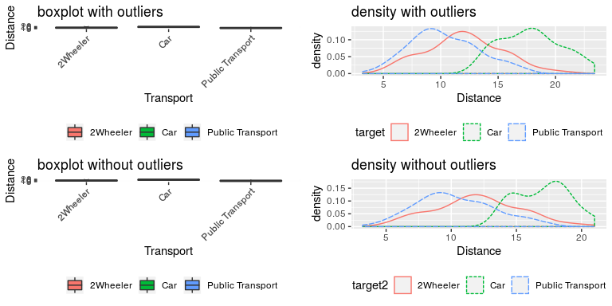

**[ license ]**  
* Distribution of license

Distribution of license

|  | total | Public Transport | Car | 2Wheeler |
| --- | --- | --- | --- | --- |
| n | 417.00 | 299.00 | 35.00 | 83.00 |
| NA | 0.00 | 0.00 | 0.00 | 0.00 |
| mean | 0.20 | 0.11 | 0.83 | 0.28 |
| sd | 0.40 | 0.31 | 0.38 | 0.45 |
| se(mean) | 0.02 | 0.02 | 0.06 | 0.05 |
| IQR | 0.00 | 0.00 | 0.00 | 1.00 |
| skewness | 1.48 | 2.50 | -1.82 | 1.01 |
| kurtosis | 0.18 | 4.28 | 1.40 | -1.00 |
| 0% | 0.00 | 0.00 | 0.00 | 0.00 |
| 1% | 0.00 | 0.00 | 0.00 | 0.00 |
| 5% | 0.00 | 0.00 | 0.00 | 0.00 |
| 10% | 0.00 | 0.00 | 0.00 | 0.00 |
| 20% | 0.00 | 0.00 | 1.00 | 0.00 |
| 25% | 0.00 | 0.00 | 1.00 | 0.00 |
| 30% | 0.00 | 0.00 | 1.00 | 0.00 |
| 40% | 0.00 | 0.00 | 1.00 | 0.00 |
| 50% | 0.00 | 0.00 | 1.00 | 0.00 |
| 60% | 0.00 | 0.00 | 1.00 | 0.00 |
| 70% | 0.00 | 0.00 | 1.00 | 0.00 |
| 75% | 0.00 | 0.00 | 1.00 | 1.00 |
| 80% | 1.00 | 0.00 | 1.00 | 1.00 |
| 90% | 1.00 | 1.00 | 1.00 | 1.00 |
| 95% | 1.00 | 1.00 | 1.00 | 1.00 |
| 99% | 1.00 | 1.00 | 1.00 | 1.00 |
| 100% | 1.00 | 1.00 | 1.00 | 1.00 |

* Visualization of Distribution

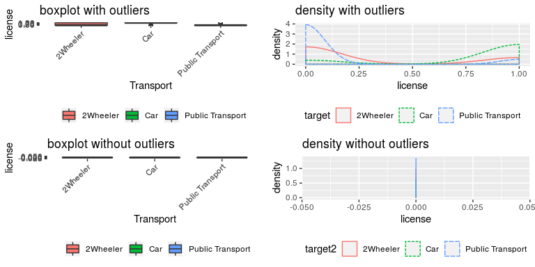

### 4.1.2 Grouped Categorical Variables

**[ Gender ]**  
* Frequency Table

Gender : frequency

|  | 2Wheeler | Car | Public Transport | Sum |
| --- | --- | --- | --- | --- |
| Female | 38 | 6 | 76 | 120 |
| Male | 45 | 29 | 223 | 297 |
| Sum | 83 | 35 | 299 | 417 |

* Relative Frequency Table (%)

Gender : ratio

|  | 2Wheeler | Car | Public Transport | Sum |
| --- | --- | --- | --- | --- |
| Female | 45.78 | 17.14 | 25.42 | 28.78 |
| Male | 54.22 | 82.86 | 74.58 | 71.22 |
| Sum | 100.00 | 100.00 | 100.00 | 100.00 |

* Visualization of Frequency

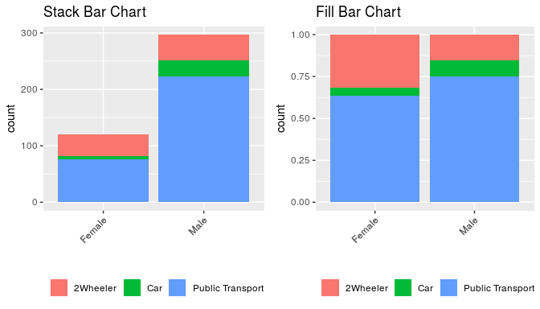

## 4.2 Grouped Relationship Between Variables

### 4.2.1 Grouped Correlation Coefficient

Table of correlation coefficients (0.5 or more)

| Transport | Variable1 | Variable2 | Correlation Coefficient |
| --- | --- | --- | --- |
| 2Wheeler | Salary | Work.Exp | 0.9031641 |
| 2Wheeler | Work.Exp | Age | 0.8134240 |
| 2Wheeler | Salary | Age | 0.7795233 |
| Car | Work.Exp | Age | 0.9526923 |
| Car | Salary | Work.Exp | 0.8478904 |
| Car | Salary | Age | 0.7847836 |
| Car | license | Salary | 0.5159742 |
| Public Transport | Salary | Work.Exp | 0.8574720 |
| Public Transport | Work.Exp | Age | 0.8480674 |
| Public Transport | Salary | Age | 0.7086209 |

### 4.2.2 Grouped Correlation Plot of Numerical Variables

```
- Grouped Correlation Case of (Transport == 2Wheeler)
```

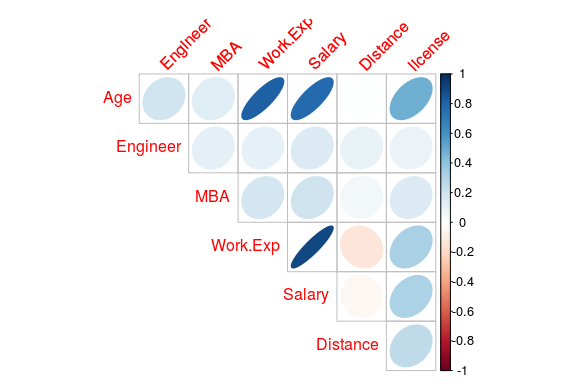

```
- Grouped Correlation Case of (Transport == Car)
```

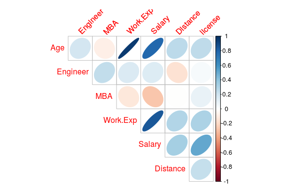

```
- Grouped Correlation Case of (Transport == Public Transport)
```

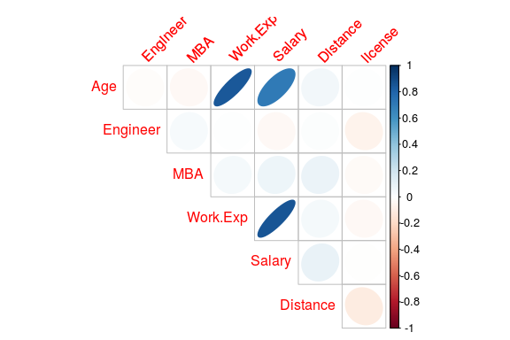

```r
#Creating the report out of the data
#create_report(raw_data)
# Embedding the report file from above step
#htmltools::includeHTML("report.html")
```

```r
head(raw_data)
```

```
##   Age Gender Engineer MBA Work.Exp Salary Distance license Transport
## 1  28   Male        1   0        5   14.4      5.1       0  2Wheeler
## 2  24   Male        1   0        6   10.6      6.1       0  2Wheeler
## 3  27 Female        1   0        9   15.5      6.1       0  2Wheeler
## 4  25   Male        0   0        1    7.6      6.3       0  2Wheeler
## 5  25 Female        0   0        3    9.6      6.7       0  2Wheeler
## 6  21   Male        0   0        3    9.5      7.1       0  2Wheeler
```

## Inferences from the EDA

Although most of the details from the above report are self explanatory, here are som e of the important ones

1. Variables “Salary”, “MBA”, “Work.Exp”, “license” are highly skewed
2. From the correlation plot, it is seen that “Age” is highly correlated to “Work Exp” and “Salary”
3. The dataset is highly imbalanced. Special techniques may be needed to balance the dataset if the models show signs of high variance

## Bivariate analysis with Target variable

1. Two wheeler and bike is famous mode of transporation among yonger people (20-30 years) and car is preferred option for people older than 30
2. People travelling longer distances prefer car
3. People without license are preferring public transport

Another challenging part is the correlations between variables. Depending on the model performance, there are chances to drop few correlated columns and also consider performing PCA.

```r
# Setting random seed to reproduce the same results everytime
set.seed(123)
library(caTools)
raw_data$MBA<-as.factor(raw_data$MBA)
#Creating dummy variables for factor column Gender
library(dummies)
raw_data<-dummy.data.frame(raw_data, names = 'Gender', omit.constants=TRUE)
```

```r
#Standardisi ng numeric columns
library(BBmisc)
num_columns <- subset(raw_data, select=c(Age,Work.Exp,Salary,Distance))
fact_columns <- subset(raw_data, select=-c(Age,Work.Exp,Salary,Distance))
scaled_columns <- normalize(num_columns, method = "range", range = c(0, 10), margin = 1L, on.constant = "quiet")
raw_data.scaled <- cbind(scaled_columns,fact_columns)
```

```r
#Splitting the dev and validation data sets 70-30 ratio
sample = sample.split(raw_data.scaled,SplitRatio = 0.7)
dev <- subset(raw_data,sample == TRUE)
val <- subset(raw_data,sample == FALSE)
```

```r
#Naive Bayes
library(e1071)

nb_gd<-naiveBayes(x=dev[,1:9], y=as.factor(dev[,10]))
#do make sure that your dependent variable is a factor

pred_nb<-predict(nb_gd,newdata = val[,1:9])

table(val[,10],pred_nb)
```

```
##                   pred_nb
##                    2Wheeler Car Public Transport
##   2Wheeler                9   0               15
##   Car                     0  12                0
##   Public Transport        9   1               79
```

```r
paste("Accuracy: ",mean(pred_nb == val$Transport))
```

```
## [1] "Accuracy:  0.8"
```

## Interpretation of Naive Bayes

The accuracy of the model is 80%, which looks like a good number. However, upon inspection of the matrix, it is evident that the model is poorly predicting the 2Wheeler. Car category is predicted perfectly but the other two categories are not as accurate and the reason I can imagine is because of highly correlated variables. Age and Experience are two variables which have equal amount of impact on the output and hence, the results. Public Transport is predicted better than the 2Wheeler may be because of the difference in the number of observation

```r
#knn compare
library(class)
knn_fit<- knn(train = dev[,1:9], test = val[,1:9], cl= dev[,10],k = 3)
#here were have predicted the  minority class all wrong. But we still do have a high probability of being correct.
#Is it a good model though?

table(val[,10],knn_fit)
```

```
##                   knn_fit
##                    2Wheeler Car Public Transport
##   2Wheeler                8   0               16
##   Car                     0  11                1
##   Public Transport        9   0               80
```

```r
paste("Accuracy: ",mean(knn_fit == val$Transport))
```

```
## [1] "Accuracy:  0.792"
```

```r
#KNN in this case is not a good algorithm to use in this case.
```

## KNN Interpretation

Almost similar results as Naive Bayes. Same comments applicable to KNN as well.

```r
#Logistic Regression.
#Using neural network to perform logistiic regression.
library(nnet)
log_reg<-multinom(Transport~.,data=dev,model = TRUE)
summary(log_reg)
```

```
## Call:
## multinom(formula = Transport ~ ., data = dev, model = TRUE)
##
## Coefficients:
##                  (Intercept)       Age GenderFemale GenderMale   Engineer
## Car               -146.27331 7.1234779   -70.970758 -75.302552 -3.8974900
## Public Transport    -4.72066 0.4996635    -3.005793  -1.714867 -0.3084847
##                        MBA1  Work.Exp      Salary   Distance  license
## Car              -1.6012689 -3.315072  0.04150752  1.4977969 10.93000
## Public Transport  0.7918595 -0.141101 -0.10093118 -0.2166891 -2.09991
##
## Std. Errors:
##                  (Intercept)       Age GenderFemale GenderMale  Engineer
## Car                0.2150876 0.3813219    1.3020751  1.1881005 2.3946457
## Public Transport   1.5732603 0.1088242    0.8171254  0.8042644 0.4017195
##                       MBA1  Work.Exp     Salary  Distance   license
## Car              2.3856455 0.8115641 0.26926476 0.5501828 2.8620108
## Public Transport 0.4298693 0.1473018 0.07027911 0.0569178 0.4557798
##
## Residual Deviance: 226.5844
## AIC: 262.5844
```

```r
logit_preds<-predict(log_reg,val[,1:9])
table(val[,10],logit_preds)
```

```
##                   logit_preds
##                    2Wheeler Car Public Transport
##   2Wheeler                9   0               15
##   Car                     3   8                1
##   Public Transport        5   0               84
```

```r
paste("Accuracy: ",mean(logit_preds == val$Transport))
```

```
## [1] "Accuracy:  0.808"
```

## Interpretation of Multinom

This model perfoms differently than the KNN and Naive Bayes Public Transport is predicted well than the other 2 classes is because of the number of observations.

```r
#Bagging
library(ipred)
library(rpart)
bag<-bagging(Transport~.,data = dev, control=rpart.control(maxdepth=15, minsplit=30,minbucket = 3,xval = 13 ))
bag_preds <- predict(bag, val[,1:9])
table(val$Transport,bag_preds)
```

```
##                   bag_preds
##                    2Wheeler Car Public Transport
##   2Wheeler               10   0               14
##   Car                     2   8                2
##   Public Transport        4   1               84
```

```r
paste("Accuracy: ",mean(bag_preds == val$Transport))
```

```
## [1] "Accuracy:  0.816"
```

```r
library(gbm)
gbm.fit <- gbm(
  formula = Transport ~ .,
  data = dev,
  n.trees = 1000,
  interaction.depth = 1,
  shrinkage = 0.001,
  cv.folds = 5,
  n.cores = NULL,
  verbose = FALSE
)
```

```
## Distribution not specified, assuming multinomial ...
```

```r
gbm_preds <- predict(gbm.fit, val[,1:9])
```

```
## Using 1000 trees...
```

```r
#we have to put type="response" just like in logistic regression else we will have log odds
gbm_preds <- apply(gbm_preds, 1, which.max)
table(val$Transport,gbm_preds)
```

```
##                   gbm_preds
##                     1  2  3
##   2Wheeler          1  0 23
##   Car               0  8  4
##   Public Transport  0  1 88
```